# MTH6139 Time Series

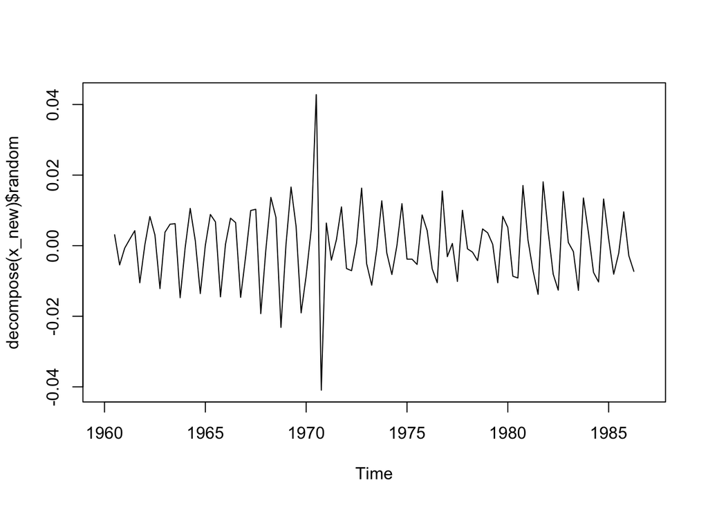

```r
x_new<-forecast::BoxCox(x,lambda) #Now we are storing the transformed data as x_new
plot(decompose(x_new)$random) #Here we plot the random component of the transformed data
```

Now, we can see that the variability of the still changes throughout time so let us try to instead do a log transformation.

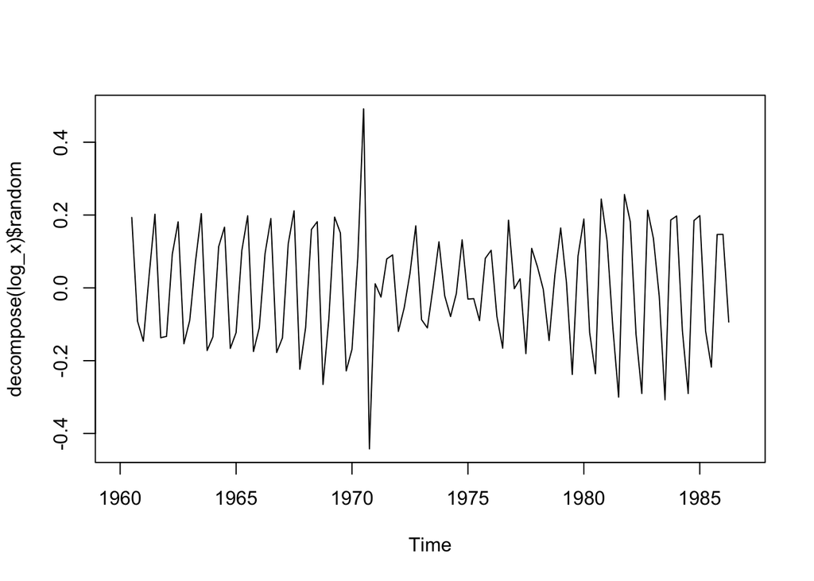

```r
log_x=log(x)
plot(decompose(log_x)$random)
```

Even still our data remains heteroskedastic so perhaps we should use a different method for forecasting. We can use Meta’s prophet tool to create a predictive model for UK gas consumption.

```r
gas.df = data.frame(ds=t,y=x) #Here, we are creating a gas data frame which is a matrix where the 1st column is our quarterly time values and the 2nd column is the gas consumption. This is needed for the prophet command
model1 = prophet(gas.df) #We create a model using the prophet modelling function
```

```
## Disabling weekly seasonality. Run prophet with weekly.seasonality=TRUE to override this.
```

```
## Disabling daily seasonality. Run prophet with daily.seasonality=TRUE to override this.
```

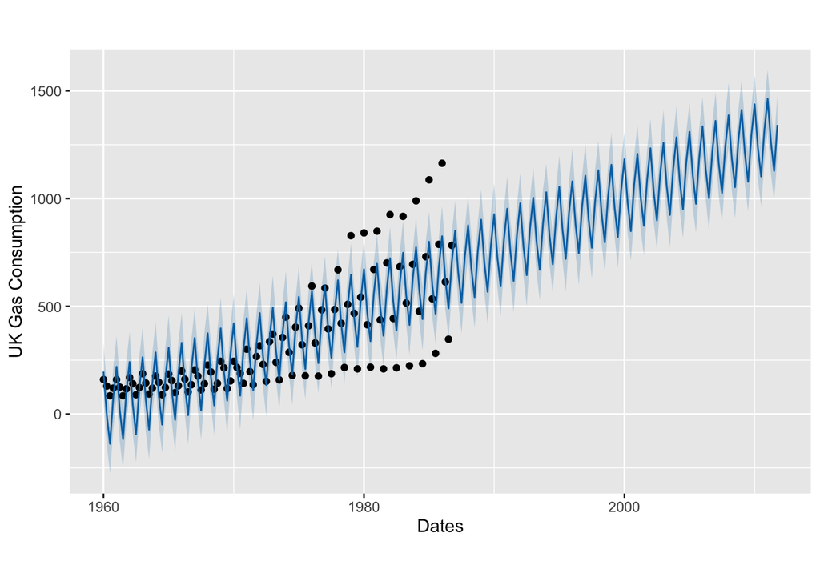

```r
future_times = make_future_dataframe(model1, periods=100, freq="quarter") #We now use this line of code to create future quarterly dates for our forecasting plot. The value 100 indicates that we will look 100 quarters into the future from our initial time series
prediction_values = predict(model1, future_times) #We use this line of code to obtain the predicted values from our prophet model
plot(model1,prediction_values,xlabel = "Dates", ylabel = "UK Gas Consumption") #Here we are producing our forecasting plot
```

This plot now indicates the predicted time series for UK Gas consumption which can be used for forecasting. The black points indicate our initial time series values and the blue line is our prediction. Meta’s Prophet tool works by creating an additive model which takes into account the trend, seasonality and residual error. However, such predictions may not be true for dates that is so far away so it would be better to reduce the time period for our forecasting model.

```r
model2 = prophet(gas.df)
```

```
## Disabling weekly seasonality. Run prophet with weekly.seasonality=TRUE to override this.
```

```
## Disabling daily seasonality. Run prophet with daily.seasonality=TRUE to override this.
```

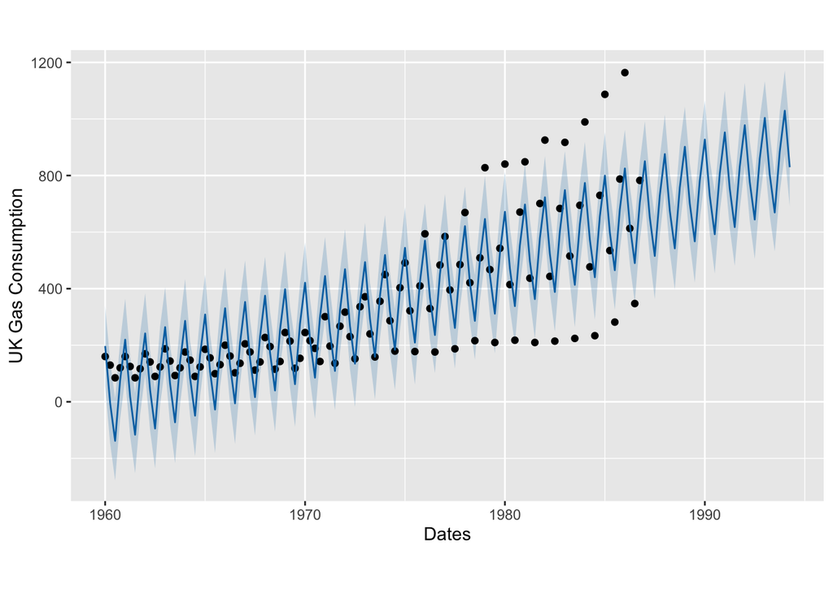

```r
future_times2 = make_future_dataframe(model2, periods=30, freq="quarter")
prediction_values2 = predict(model2, future_times2)
plot(model2,prediction_values2,xlabel = "Dates", ylabel = "UK Gas Consumption")
```

This is perhaps a more accurate model since the time frame for predictions is much shorter.